# Exploring 2012 Presidential Campaign Contributions in Ohio by Aaron Rank

### What do you know by analyzing three or more variables?

## Gender, Contribution Amount, Contribution Date, Candidate Party

```r
data$contbr_fnm <- sapply(data$contbr_nm, function(name) {
       f.name <- str_extract(as.character(name),", [[:alpha:]]+($|[[:space:]])")
       f.name <- str_replace(f.name,", ","")
       f.name <- str_trim(f.name)
       return(as.character(f.name))

  })
write.csv(data,'~/projects/udacity_DataR/data_gender_pred.csv')
data$doctor <- sapply(as.character(data$contbr_nm), function(name){
  if (grepl("DR.",name)) {
    return("Doctor")
  }
  else {
    return("Not Doctor")
  }
})
data$gender<- sapply(as.character(data$contbr_nm), function(name) {

                  if(grepl("MRS.",name)){
                    return("female")
                  }
                  else if(grepl("MR.",name)){
                      return("male")
                  }
                  else if(grepl(" MS.",name)){
                    return("female")
                  }
                  else{
                    return(as.character(NA))
                  }
                })
gender <- subset(data,gender == "male" | gender == "female")
table(gender[c('gender','cand_party')])
```

```
##         cand_party
## gender       D     R
##   female     2  6273
##   male     136 12803
```

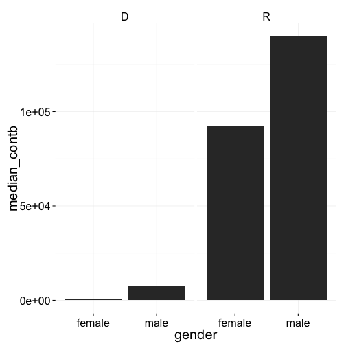

```r
data.gender <- groupData(gender, contb_receipt_amt, gender, cand_party)


ggplot(data.gender,aes(gender, median_contb)) + geom_bar(stat='identity') + facet_wrap(~ cand_party)
```

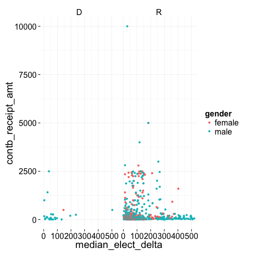

```r
ggplot(data.gender, aes(x=median_elect_delta, y=contb_receipt_amt,color=gender)) + geom_point() + facet_wrap(~ cand_party)
```

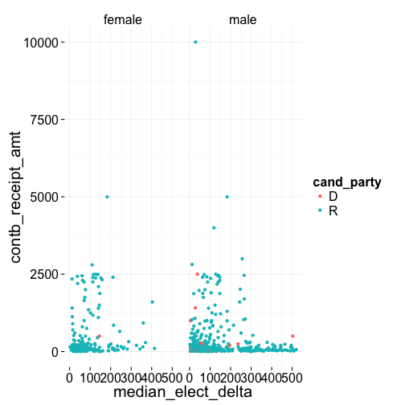

```r
ggplot(data.gender, aes(x=median_elect_delta, y=contb_receipt_amt,color=cand_party)) + geom_point() + facet_wrap(~ gender)
```

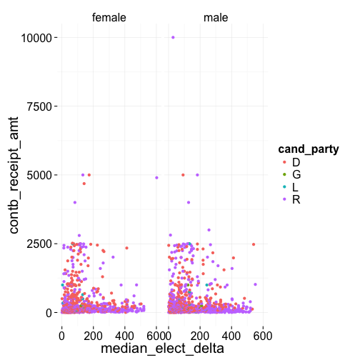

```r
data.gender.predicted <- read.csv('~/projects/udacity_DataR/data_gender_predicted.csv')


data.predicted <- groupData(data.gender.predicted, contb_receipt_amt, predicted_gender, cand_party)

ggplot(data.predicted, aes(x=median_elect_delta, y=contb_receipt_amt,color=cand_party)) + geom_point() + facet_wrap(~ predicted_gender)
```

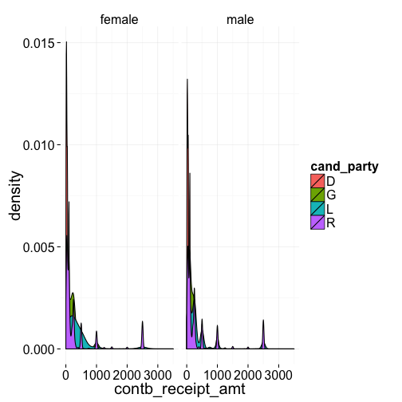

```r
ggplot(data.gender.predicted,aes(contb_receipt_amt,fill=cand_party)) + geom_density() + facet_wrap(~ predicted_gender) + xlim(0,3500)
```

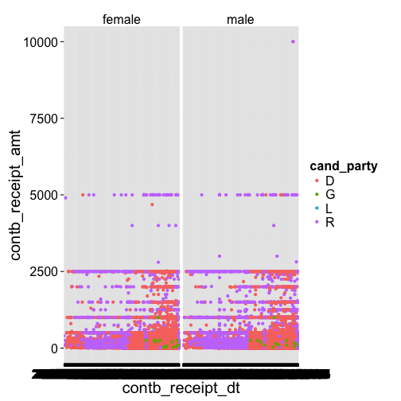

```r
ggplot(data.gender.predicted,aes(contb_receipt_dt,contb_receipt_amt,color=cand_party)) + geom_point() + facet_wrap(~ predicted_gender)
```

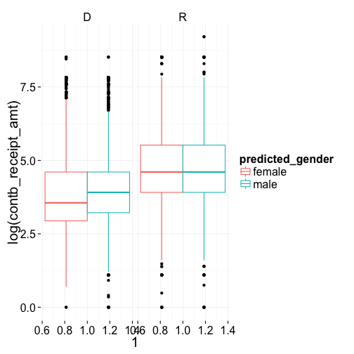

```r
ggplot(subset(data.gender.predicted,cand_party=='D' | cand_party=='R'),aes(x=1,log(contb_receipt_amt),color=predicted_gender)) + geom_boxplot() + facet_wrap(~ cand_party)
```

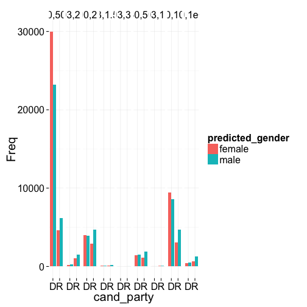

```r
count.by.gender.party <- ggplot(as.data.frame(table(data.gender.predicted[c('predicted_gender','cand_party')])),aes(x=cand_party,y=Freq,fill=predicted_gender)) + geom_bar(stat='identity', position=position_dodge())

tmp <- subset(data.gender.predicted, cand_party=='D'| cand_party=='R')
tmp$cand_party <- as.character(tmp$cand_party)

gender.party.contb_bins <- as.data.frame(table(tmp[c('predicted_gender','cand_party','contb_bins')]))
ggplot(gender.party.contb_bins,aes(x=cand_party,y=Freq,fill=predicted_gender)) + geom_bar(stat='identity',position=position_dodge()) + facet_grid(~ contb_bins)
```

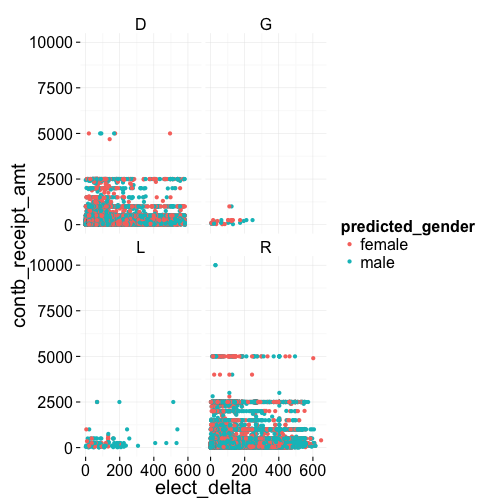

```r
ggplot(data.gender.predicted,aes(x=elect_delta, y=contb_receipt_amt, color=predicted_gender)) + geom_point() + facet_wrap(~ cand_party)
```

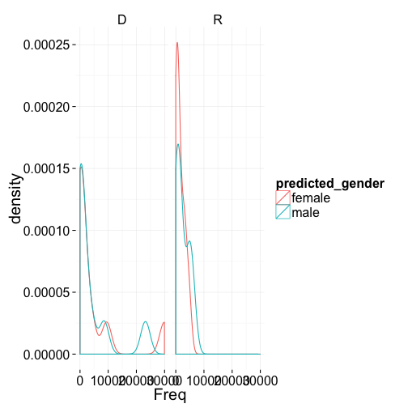

```r
ggplot(gender.party.contb_bins,aes(Freq, color=predicted_gender)) + geom_density()  + facet_wrap(~ cand_party)
```

```r
male <- subset(data.gender.predicted,predicted_gender=='male')
female <- subset(data.gender.predicted,predicted_gender=='female')

r <- subset(data.gender.predicted, cand_party == 'R')
d <- subset(data.gender.predicted, cand_party == 'D')

d.gen <- ifelse(d$predicted_gender == "male",1,0)
r.gen <- ifelse(r$predicted_gender == "male",1,0)

dd <- sample(d.gen, 10000)
rr <- sample(r.gen, 10000)

cand_party <- ifelse(subset(data, cand_party == 'D' | cand_party == 'R')$cand_party == 'D', 1, 0)
BernBeta(c(0,1),sample(cand_party,30000))
```

[output not shown]

```r
BernBeta(c(1,1),rr)
```

[output not shown]

```r
BernBeta(c(1,1),dd)
```

[output not shown]

```r
m <- ifelse(male$cand_party == "D",1,0)
f <- ifelse(female$cand_party == "D",1,0)
f <- ifelse(r.gen$predicted_gender == "male",1,0)
```

[output not shown]

```r
t.test(d.gen$predicted_gender,r.gen$predicted_gender)
```

[output not shown]

```r
sourceDir <- function(path, trace = TRUE, ...) {
    for (nm in list.files(path, pattern = "\\.[RrSsQq]$")) {
       if(trace) cat(nm,":")
       source(file.path(path, nm), ...)
       if(trace) cat("\n")
    }
}
sourceDir('/users/aaronrank/projects/udacity_DataR/DBDA2/')
```

Out of the ~19,000 records where the contributor provided an indication of their gender by using “MS.”, “MRS.”, or “MR.” and where the contribution amount was greater than 0, only 138 contributed to Democratic campaigns. Of these 138, 2 used “MRS.” or “MS.” and 136 used “MR.”. Using the way back machine, I looked at the Obama and Romney donation page on their website - neither seemed to ask for gender nor have a form for the donor to include their salutation. It could be that Democrats are less likely to associate or define themselves by gender or that younger people are less likely to do this (Democrats tend to be younger than Republicans). Regardless of the reason, creating a feature out of this information could be useful in predicting in which party the donor made their contribution.

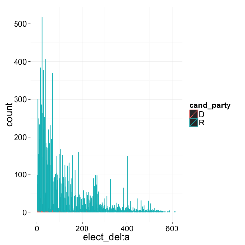

```r
data.party.elect_delta <- groupData(data,cand_party,elect_delta)
ggplot(data.party.elect_delta,aes(x=elect_delta, y=count)) + geom_bar(stat='identity',aes(group=cand_party,color=cand_party))
```

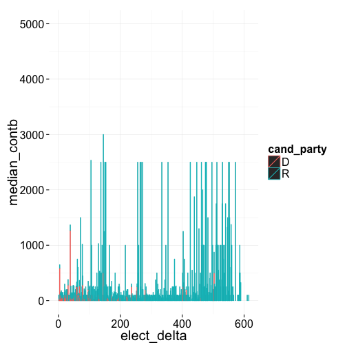

```r
ggplot(data.party.elect_delta,aes(x=elect_delta, y=median_contb)) + geom_bar(stat='identity',aes(group=cand_party,color=cand_party)) + ylim(0,5000)# Republicans consistently made higher contributions
```

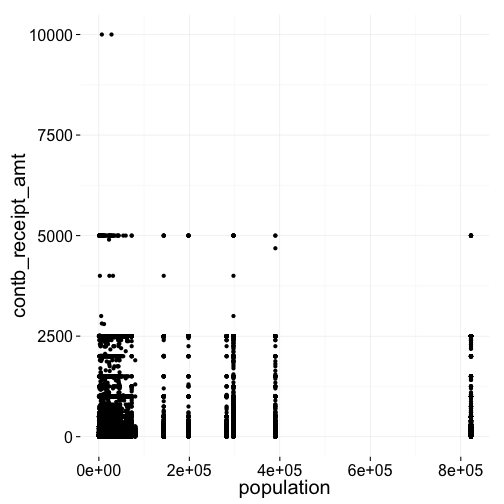

```r
ggplot(data,aes(x=population,y=contb_receipt_amt)) + geom_point()
```

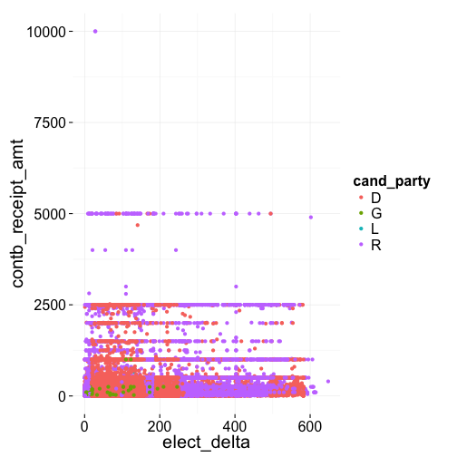

```r
ggplot(data,aes(x=elect_delta,y=contb_receipt_amt)) + geom_point(aes(color=cand_party)) #+ ylim(0,5500)
```

### gender

# Final Plots and Summary

# Reflection